# Mid-Term Examination

Shude Guo

```r
library(tidyverse)
library(factoextra)
library(ISLR)
library(flexclust)
setwd("~/Desktop")
Universities <- read.csv("Universities.csv")
```

### Question 1

```r
U <- na.omit(Universities)
head(U)
```

```
##                           College.Name State Public..1...Private..2.
## 1            Alaska Pacific University    AK                       2
## 3       University of Alaska Southeast    AK                       1
## 10         Birmingham-Southern College    AL                       2
## 12                  Huntingdon College    AL                       2
## 22                   Talladega College    AL                       2
## 26 University of Alabama at Birmingham    AL                       1
##    X..appli..rec.d X..appl..accepted X..new.stud..enrolled
## 1              193               146                    55
## 3              146               117                    89
## 10             805               588                   287
## 12             608               520                   127
## 22            4414              1500                   335
## 26            1797              1260                   938
##    X..new.stud..from.top.10. X..new.stud..from.top.25. X..FT.undergrad
```

[output cut: 27 more lines]

### Question 2

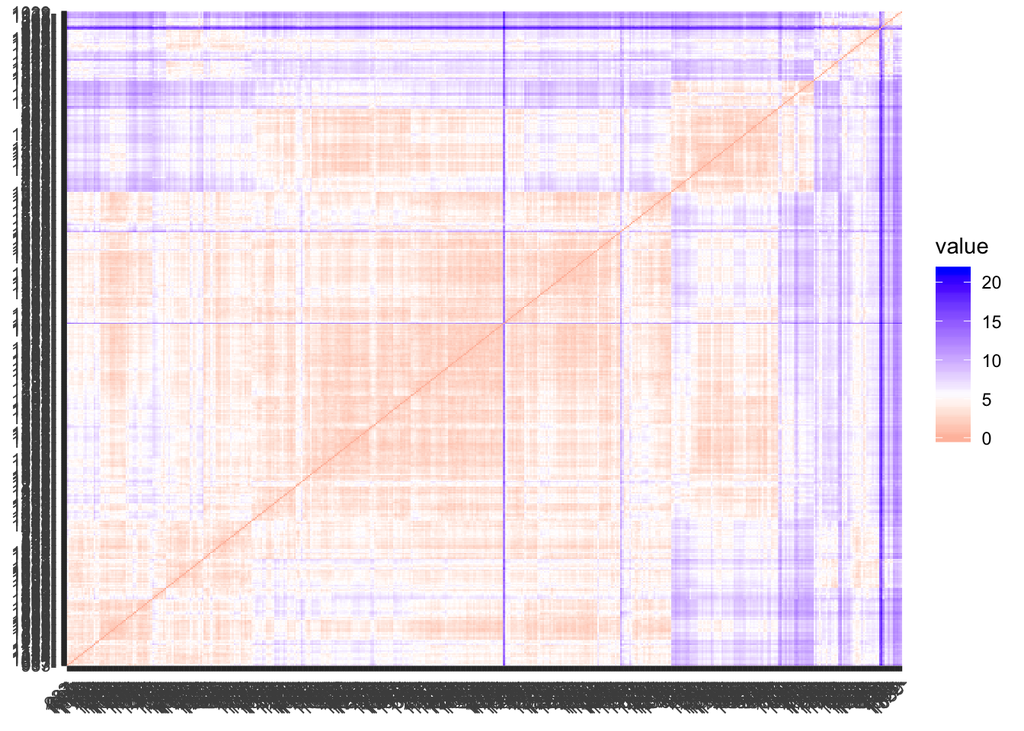

```r
set.seed(123)
df <- U[,c(4,5,6,7,8,9,10,11,12,13,14,15,16,17,18,19,20)]
df <- scale(df)
distance <- get_dist(df)
fviz_dist(distance)
```

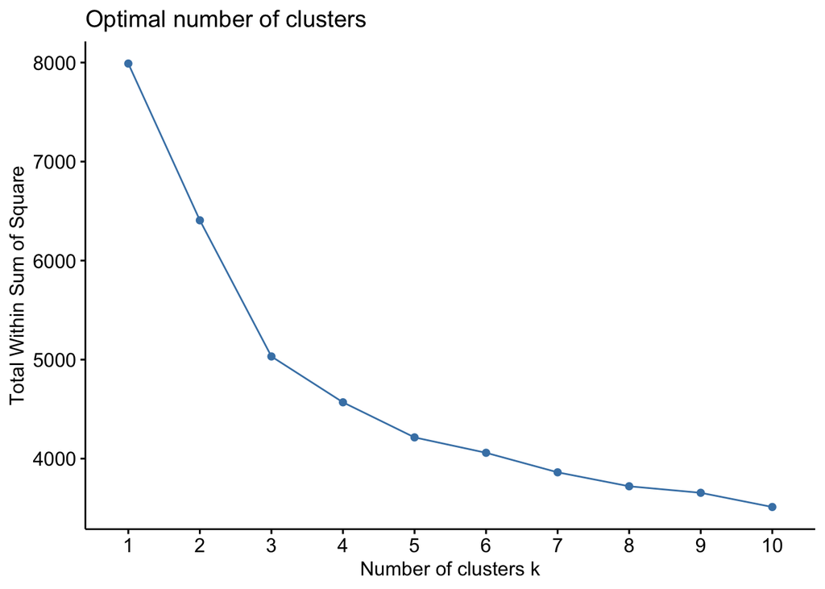

```r
fviz_nbclust(df, kmeans, method = "wss")
```

```r
k5 <- kmeans(df, centers = 5, nstart = 25)
k5$centers
```

```
##   X..appli..rec.d X..appl..accepted X..new.stud..enrolled
## 1       2.3016968         2.5572926            2.69693471
## 2      -0.5569125        -0.5531207           -0.54647592
## 3       0.1682069         0.2029277            0.37049207
## 4      -0.3426507        -0.2983104           -0.37339353
## 5       0.5133052         0.1878958            0.04207847
##   X..new.stud..from.top.10. X..new.stud..from.top.25. X..FT.undergrad
## 1                 0.2040698                 0.3588871      2.72119433
## 2                -0.6251217                -0.7320661     -0.52891250
## 3                -0.5783497                -0.4956370      0.44673975
## 4                 0.1396486                 0.2637985     -0.39038553
## 5                 1.7941218                 1.5251765     -0.07715163
##   X..PT.undergrad in.state.tuition out.of.state.tuition       room
## 1       1.8684008       -1.0036600           -0.4071160  0.0603682
## 2      -0.2502879       -0.2224986           -0.4869970 -0.4735431
## 3       0.3577778       -1.2804094           -1.0816909 -0.4494664
## 4      -0.2741592        0.5591155            0.4758599  0.1946075
## 5      -0.3735320        1.5152395            1.7021870  1.2108424
##         board  add..fees estim..book.costs estim..personal.. X..fac..w.PHD
## 1 -0.09220051  0.6367769        0.23336269        0.89689582     0.7545890
## 2 -0.41288238 -0.4013105       -0.04908761        0.07727633    -1.0623362
## 3 -0.71584374  0.5456475       -0.02813158        0.37150911     0.0713757
## 4  0.39150003 -0.1345900       -0.12879063       -0.30974761     0.3363365
## 5  1.03863100  0.1320633        0.33234082       -0.47423704     1.0915826
##   stud..fac..ratio Graduation.rate
## 1       0.49690676      -0.1397266
## 2       0.06652033      -0.5386811
## 3       1.00678771      -0.6683725
## 4      -0.27596976       0.4447424
## 5      -1.16554722       1.1647914
```

```r
k5$size
```

```
## [1]  37 141  83 150  60
```

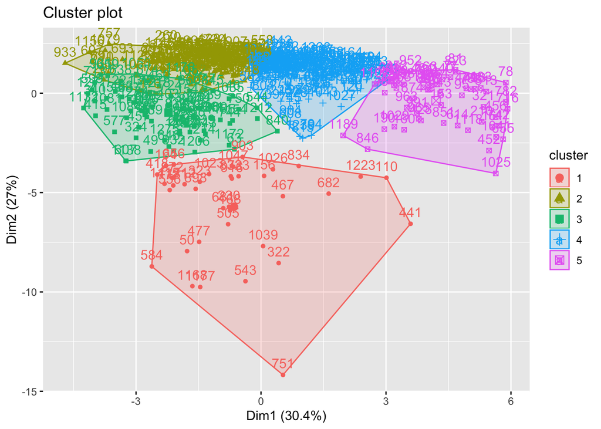

```r
fviz_cluster(k5, data = df)
```

### Question 3

#### Cluster 1: High application rate, high admission rate, high enrollment rate, high full-time undergraduate rate, low tuition.

#### Cluster 2: Low composite index, lower faculty with PHD ratio.

#### Cluster 3: Composite index is relatively average, low tuition, higher student and faculty ratio.

#### Cluster 4: Composite index is relatively average.

#### Cluster 5: Higher ratio on students from the top 10% and top 25%, higher tuition, higher ratio of room and board, higher faculty with PHD ratio, lower student and faculty ratio, higher graduation rate.

### Question 4

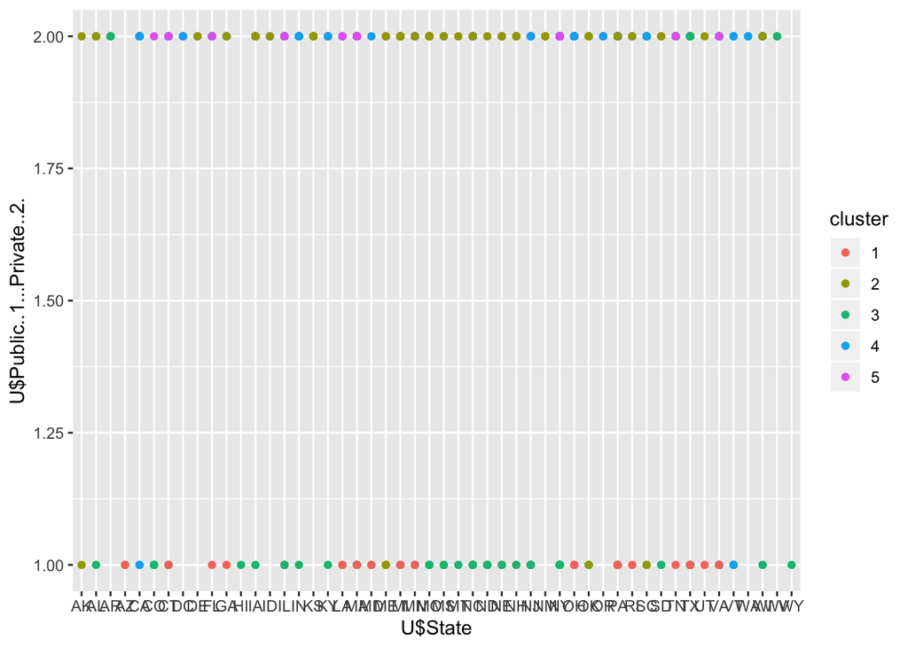

```r
U_clustered <- data.frame(U, cluster=factor(k5$cluster))
ggplot(U_clustered, aes(x=U$State, y=U$Public..1...Private..2., color=cluster)) + geom_point()
```

#### Clusters 1 and 3 are mostly distributed in public schools sector, while clusters 2, 4 and 5 are mostly distributed in private schools sector.

### Question 5

#### The data of cluster 5 has the characteristics of lower student and faculty ratio, while cluster 2 and 4 also have a medium and low ratio in the student and faculty ratio. It can be inferred that private schools have higher admission thresholds, or lower application and acceptance rates.

### Question 6

```r
k5
```

```
## K-means clustering with 5 clusters of sizes 37, 141, 83, 150, 60
##
## Cluster means:
##   X..appli..rec.d X..appl..accepted X..new.stud..enrolled
## 1       2.3016968         2.5572926            2.69693471
## 2      -0.5569125        -0.5531207           -0.54647592
## 3       0.1682069         0.2029277            0.37049207
## 4      -0.3426507        -0.2983104           -0.37339353
## 5       0.5133052         0.1878958            0.04207847
##   X..new.stud..from.top.10. X..new.stud..from.top.25. X..FT.undergrad
## 1                 0.2040698                 0.3588871      2.72119433
## 2                -0.6251217                -0.7320661     -0.52891250
## 3                -0.5783497                -0.4956370      0.44673975
## 4                 0.1396486                 0.2637985     -0.39038553
## 5                 1.7941218                 1.5251765     -0.07715163
```

[output cut: 94 more lines]

```r
set.seed(123)
k5 = kcca(df, k=5, kccaFamily("kmeans"))
k5
```

```
## kcca object of family 'kmeans'
##
## call:
## kcca(x = df, k = 5, family = kccaFamily("kmeans"))
##
## cluster sizes:
##
##   1   2   3   4   5
## 125  40   4 105 197
```

```r
clusters_index <- predict(k5)
dist(k5@centers)
```

```
##          1        2        3        4
## 2 6.743620
## 3 7.059847 8.558978
## 4 5.367446 5.480050 6.608182
## 5 3.700143 6.837946 6.188979 2.769468
```

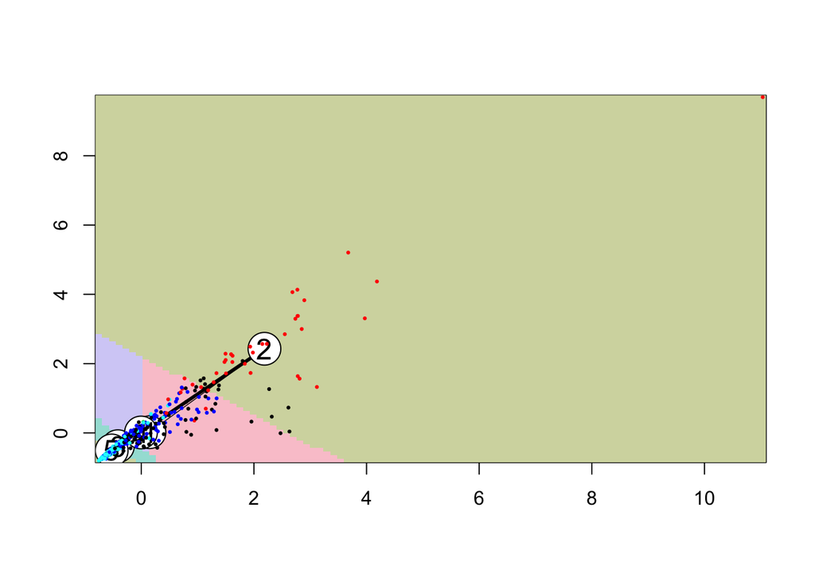

```r
image(k5)
points(df, col=clusters_index, pch=19, cex=0.3)
```